### Plotting of 6 clusters

### We use PCA i.e, Principal Component Analysis

```r
pcclust= prcomp(customer_data[,3:5],scale=FALSE) #PCA
summary(pcclust)
```

```
## Importance of components:
##                            PC1     PC2     PC3
## Standard deviation     26.4625 26.1597 12.9317
## Proportion of Variance  0.4512  0.4410  0.1078
## Cumulative Proportion   0.4512  0.8922  1.0000
```

```r
pcclust$rotation[,1:2]
```

```
##                               PC1        PC2
## Age                     0.1889742 -0.1309652
## Annual.Income..k..     -0.5886410 -0.8083757
## Spending.Score..1.100. -0.7859965  0.5739136
```

```r
k6<-kmeans(customer_data[,3:5],6,iter.max=100,nstart=50,algorithm="Lloyd")
```

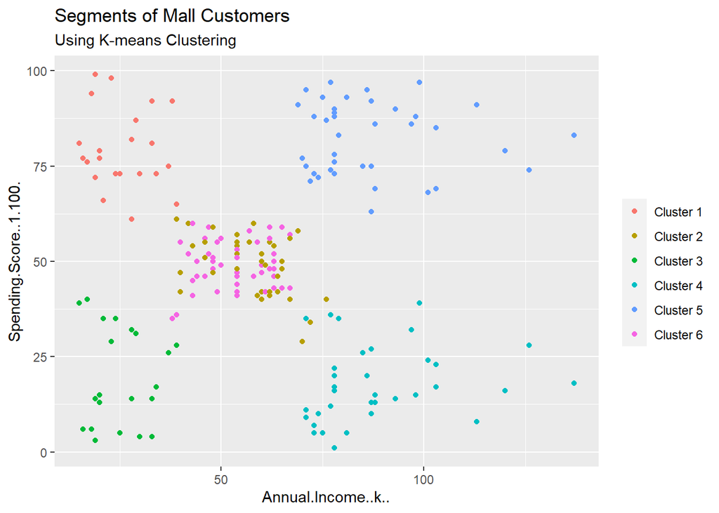

```r
# annual income vs spending score clusters
library(ggplot2)
ggplot(customer_data, aes(x =`Annual.Income..k..`, y = `Spending.Score..1.100.`)) +
  geom_point(stat = "identity", aes(color = as.factor(k6$cluster))) +
  scale_color_discrete(name=" ",breaks=c("1", "2", "3", "4", "5","6"), labels=c("Cluster 1", "Cluster 2", "Cluster 3", "Cluster 4", "Cluster 5","Cluster 6")) +
  ggtitle("Segments of Mall Customers", subtitle = "Using K-means Clustering")
```

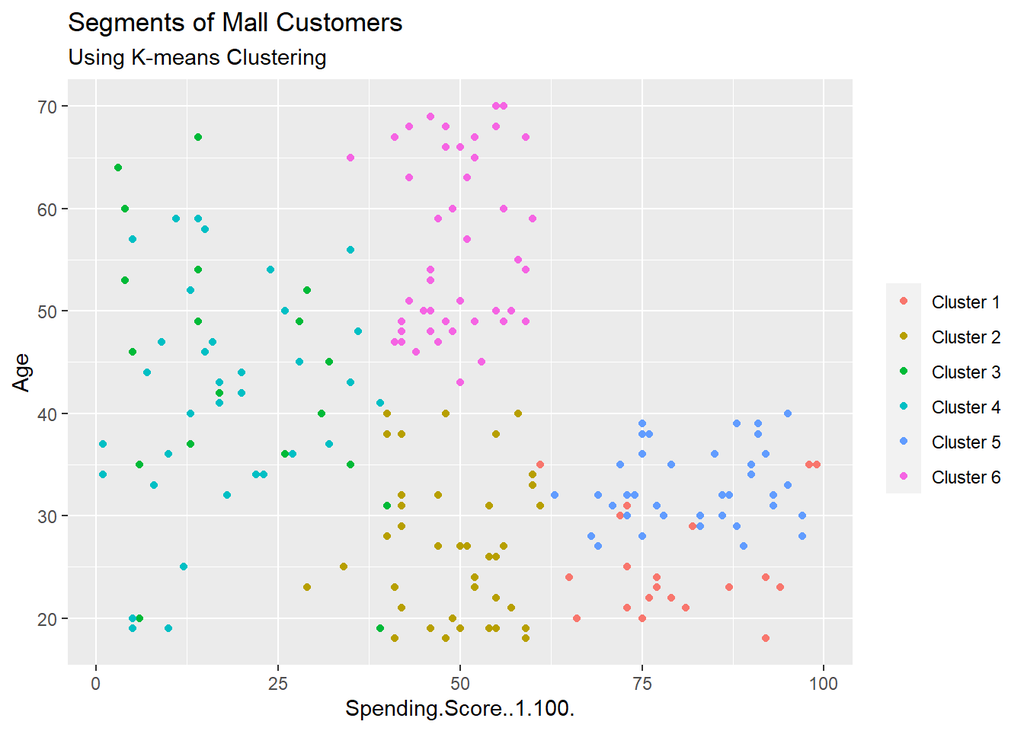

```r
#spending score vs age clusters
ggplot(customer_data, aes(x =`Spending.Score..1.100.`, y =Age)) +
  geom_point(stat = "identity", aes(color = as.factor(k6$cluster))) +
  scale_color_discrete(name=" ",breaks=c("1", "2", "3", "4", "5","6"),labels=c("Cluster 1", "Cluster 2", "Cluster 3", "Cluster 4", "Cluster 5","Cluster 6")) +
  ggtitle("Segments of Mall Customers", subtitle = "Using K-means Clustering")
```

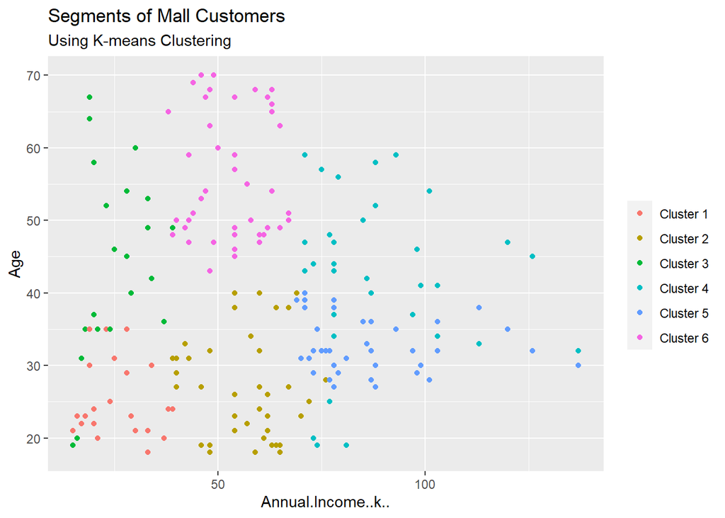

```r
#annual income vs age clusters
ggplot(customer_data, aes(x =`Annual.Income..k..`, y =Age)) +
  geom_point(stat = "identity", aes(color = as.factor(k6$cluster))) +
  scale_color_discrete(name=" ",breaks=c("1", "2", "3", "4", "5","6"),labels=c("Cluster 1", "Cluster 2", "Cluster 3", "Cluster 4", "Cluster 5","Cluster 6")) +
  ggtitle("Segments of Mall Customers", subtitle = "Using K-means Clustering")
```

## Analysis

#### Mapping clusters back to the data to see which customer belongs to which cluster

#### Let’s Map all the 6 Clusters to the data set.

```r
# In R, the order() function is used to obtain the order or permutation of the indices that would sort a vector or a set of vectors. This function is often used to sort data or reorganize it based on specific criteria.

o = order(k6$cluster)

# Using only customer ID for easy tracking instead of the whole dataset.
data.frame(customer_data$CustomerID[o],k6$cluster[o])
```

```
##     customer_data.CustomerID.o. k6.cluster.o.
## 1                             2             1
## 2                             4             1
## 3                             6             1
## 4                             8             1
## 5                            10             1
## 6                            12             1
## 7                            14             1
## 8                            16             1
## 9                            18             1
## 10                           20             1
## 11                           22             1
## 12                           24             1
## 13                           26             1
## 14                           28             1
```

[output cut: 186 more lines]

```r
# mapping using all the other columns i.e, to the entire dataset

x = data.frame(customer_data$CustomerID[o], customer_data$Gender[o], customer_data$Age[o], customer_data$`Annual.Income..k..`[o], customer_data$`Spending.Score..1.100.`[o],k6$cluster[o])
```

### Conclusion

1. The dataset contains information about customers, including gender, age, annual income, and spending score.
2. No missing values were found in the dataset, ensuring completeness for analysis.
3. Summary statistics and visualizations were generated for key variables like age, annual income, and spending score.
4. Histograms and box plots provided insights into the distribution and central tendencies of these variables.
5. Bar plots and pie charts were used to visualize the gender distribution among customers.
6. It was observed that there were more female customers compared to male customers.
7. The K-means algorithm was applied to cluster customers into segments based on annual income, spending score, and age.
8. The silhouette method and the elbow method were used to determine the optimal number of clusters, which was found to be 6.
9. Visualization of clusters using scatter plots revealed distinct segments with different characteristics.
10. Each cluster was analyzed to understand the characteristics of customers within them.
11. Clusters were differentiated based on factors such as high/low annual income, high/low spending score, and age groups.
12. Interpretation of clusters allowed for targeted marketing strategies and personalized customer engagement.
13. Customer segmentation is crucial for tailoring marketing strategies to specific customer groups.
14. The identified clusters provide a basis for targeted advertising, promotions, and services.
15. Understanding customer segments can lead to improved customer satisfaction and increased business revenue.